# Numerical Methods for PDEs (Spring 2017), Practical 2

Richard Southwell, Gustav Delius

## Lists

A vector is a collection of elements of the same class. If we want to group up elements of different classes, we can use a `list`. For example, the code below makes a list including a character vector and a numeric vector:

```r
myList <- list(animal=c("dog", "man"), legs=c(4, 2))
myList
```

```
$animal
[1] "dog" "man"

$legs
[1] 4 2
```

You can extract an component of the list either by name, separating the name of the list and the name of the component by a $,

```r
myList$legs
```

```
[1] 4 2
```

or by index, using double square brackets around the index of the component:

```r
myList[[2]]
```

```
[1] 4 2
```

Single square bracket notation also works, but it returns a list:

```r
myList[2]
```

```
$legs
[1] 4 2
```

## Creating Functions

R has many built in functions, and we can create more. Let us make a function `circle()`, which takes two inputs arguments: `N` and `r`, and outputs the coordinates of `N` points equally spaced around a circle of radius `r`.

```r
circle <- function(N, r) {
    t <- (1:N)/N
    A <- list(x=r*sin(2*pi*t), y=r*cos(2*pi*t))
    return(A)
}
```

This function creates a list `A` with two components: `A$x` is a vector with the x-coordinates of our circle points, and `A$y` is a vector with the y-coordinates of the circle points. Let us check this function works.

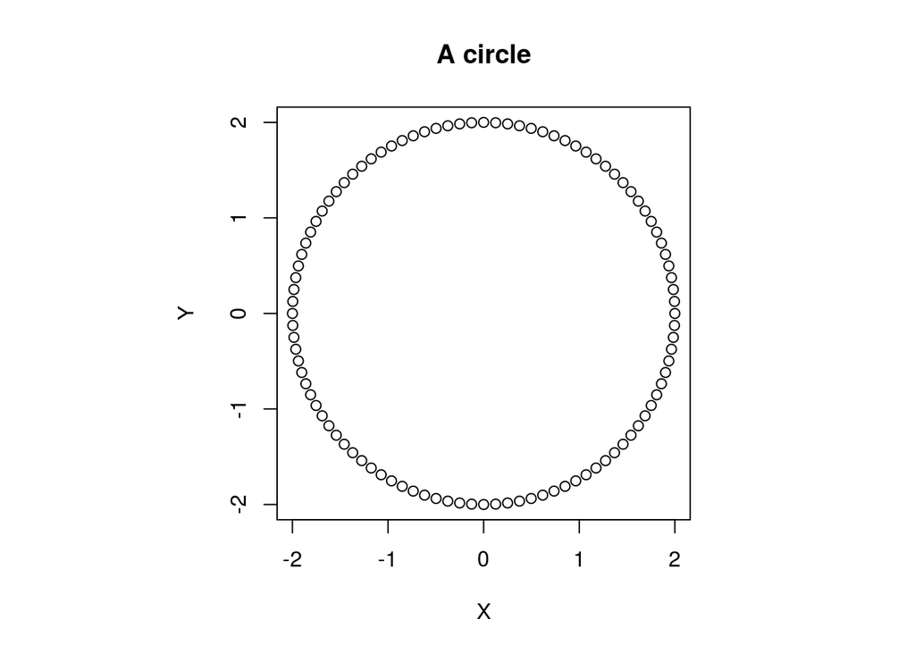

```r
coords <- circle(100, 2)
par(pty="s")
plot(coords$x, coords$y, main="A circle", xlab="X", ylab="Y")
```

```r
par(pty="m")
```

Recall from last time that we need to change R’s plotting parameters using `par(pty="s")` to get the axes to have the same length, and after we are done we reset the parameters with `par(pty="m")`.

The variables `N,r,A,t` are defined locally inside our circle function, so if we use variables `t` or `N` in our global environment, they will be independent of the similarly named variables inside our `circle()` function and will not be changed when we call the `circle()` function

```r
t <- 1
N <- 2
circle(5,3)
```

```
$x
[1]  2.853170e+00  1.763356e+00 -1.763356e+00 -2.853170e+00 -7.347881e-16

$y
[1]  0.927051 -2.427051 -2.427051  0.927051  3.000000
```

```r
t
```

```
[1] 1
```

Regarding plotting, we again set`type = "l"` to make a plot with lines. Additional lines can be added using the `lines` command. We add one more line to close the hexagon in this case.

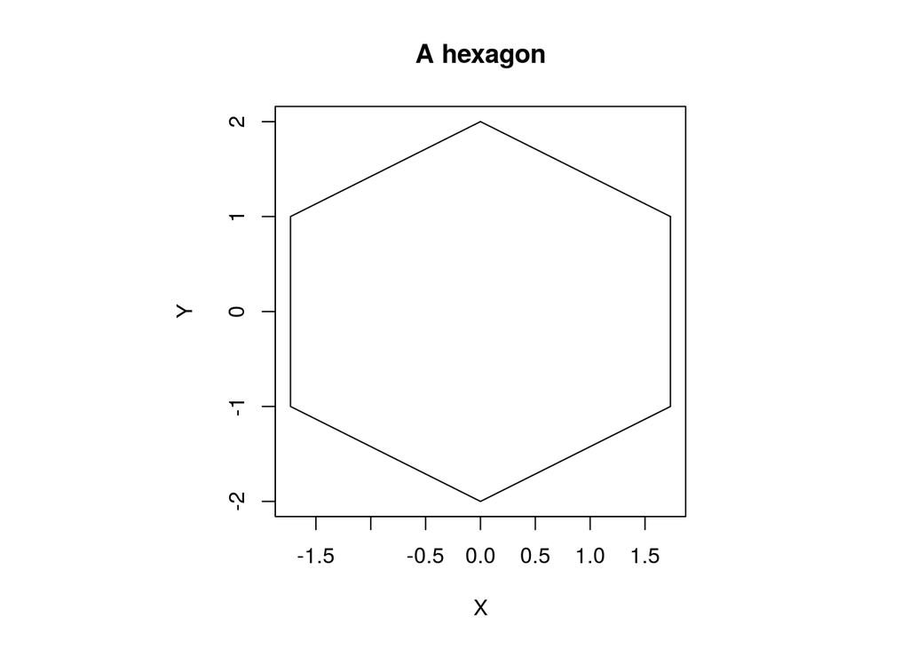

```r
coords <- circle(6, 2)
par(pty="s")
plot(coords$x, coords$y, main="A hexagon", xlab="X", ylab="Y", type = "l")
lines(c((coords$x)[6], (coords$x)[1]), c((coords$y)[6], (coords$y)[1]))
```

```r
par(pty="m")
```

It is possible to refer to variables inside a function, which are not inputs and which are not defined inside a function. When R encounters such variables it looks to see if they are defined at a higher level. For example, let us write another function, that generates a circle, but this time it will be shifted `w` units to the right:

```r
shiftedCircle <- function(N, r) {
    t <- (1:N)/N
    A <- list(x=r*sin(2*pi*t) + w, y=r*cos(2*pi*t))
    return(A)
}
```

Let us test our function:

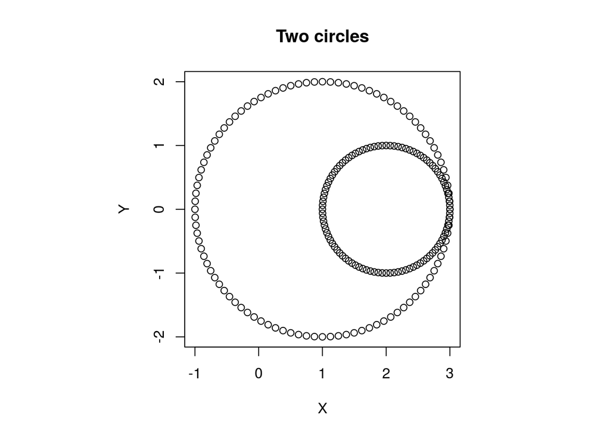

```r
w <- 1
par(pty="s")
plot(shiftedCircle(100, 2)$x, shiftedCircle(100, 2)$y,
     main="Two circles", xlab="X", ylab="Y")
w <- 2
points(shiftedCircle(100, 1)$x, shiftedCircle(100, 1)$y)
```

```r
par(pty="m")
```

This `plot` command makes a radius two circle with a centre one unit to the right of the origin. The `points` command adds extra points, in this case for a radius one circle with a centre two units to the right of the origin.

## Loops

The `for` loop repeats a group of statements a fixed, predetermined number of times. The statements to be repeated are enclosed in curly brackets:

```r
for (n in 1:3) {
    print(n/2)
}
```

```
[1] 0.5
[1] 1
[1] 1.5
```

In this example, we make a vector `f` of ones, and then use a `for` loop to rewrite it with the Fibonacci numbers:

```r
f <- rep(1, 10)
f
```

```
 [1] 1 1 1 1 1 1 1 1 1 1
```

```r
for (n in 3:10) {
    f[n] <- f[n-1] + f[n-2]
}
f
```

```
 [1]  1  1  2  3  5  8 13 21 34 55
```

We can fill in a matrix by nesting one for loop inside another:

```r
H <- matrix(0, 5, 5)
for (n in 1:5) {
    for (m in 1:5) {
        H[n, m] <- 1/(n+m)
    }
}
H
```

```
          [,1]      [,2]      [,3]      [,4]      [,5]
[1,] 0.5000000 0.3333333 0.2500000 0.2000000 0.1666667
[2,] 0.3333333 0.2500000 0.2000000 0.1666667 0.1428571
[3,] 0.2500000 0.2000000 0.1666667 0.1428571 0.1250000
[4,] 0.2000000 0.1666667 0.1428571 0.1250000 0.1111111
[5,] 0.1666667 0.1428571 0.1250000 0.1111111 0.1000000
```

Note that we have indented the code inside the loops. Indenting like this is not necessary for the code to run, but it is a helpful programming convention that makes it easier for other people to read the code. RStudio’s automation helps you to indent your code appropriately as you type in script files.

The `while` loop repeats a group of statements an indefinite number of times under control of a logical condition. For example, the following program computes all powers of 2 that are less that 1000 and writes the result as a vector `q`. Here `q` starts as an empty vector, and we build `q` up by appending new entries to its right hand side:

```r
s <- 2
q <- c()
while(s < 1000) {
    q <- c(q, s)
    s <- 2*s
}
q
```

```
[1]   2   4   8  16  32  64 128 256 512
```

The function file below approximates function $e^x$ by its $N$th Taylor polynomial at 0, i.e. it computes

$$1+x+\frac{x^2}{2!} + ... + \frac{x^n}{N!} = \sum_{k=0} ^N c_k$$
where $c_k = x^k / k!$ can be computed recursively since $c_0 = 1$ and $c_k = c_{k-1} x /k.$

```r
myexp <- function(x, N) {
    f <- 1
    c <- 1
    for (k in 1:N) {
        c <- c*x/k
        f <- f+c
    }
    return(f)
}
myexp(1, 5)
```

```
[1] 2.716667
```

### Exercise 1

Write a function `mysum` that uses a loop to compute
$$\frac{1}{1^2}+\frac{1}{2^2}+\frac{1}{3^2}+...+\frac{1}{N^2}$$
for a given $N$. Compute the sum for $N=10, 50, 100.$

### Exercise 2

Use a `for` loop within which our `circle` function is repeatedly called, to make a picture with seven concentric circles, of radii 1,2,..,7.

## If and Break

The `if` statement evaluates a logical expression and executes a group of statements (surrounded in curly brackets) when the expression is `TRUE`. The optional `else if` and `else` keywords provide for the execution of alternate groups of statements.

```r
x <- 0
if (x < 0) {
   print("Negative number")
} else if (x > 0) {
   print("Positive number")
} else {
    print("Zero")
}
```

```
[1] "Zero"
```

The command `break` inside a for or while loop terminates the execution of the loop. In this example we iterate the logistic map $x \rightarrow 2.5 x (1-x)$ until updating causes the value to change by less than $0.001.$

```r
x <- 0.5
for (j in 1:100) {
    y <- 2.5*x*(1-x)
    if (abs(x-y) < 0.001) {
        break
    } else {
        x <- y
    }
}
y
```

```
[1] 0.5997913
```

### Exercise 3

Write a function `mysin` which approximates $\sin(x)$ by its Taylor series at $0$ with error less than $10^-4.$ The Taylor formula is
$$\sin(x) = x - \frac{x^3}{3!} + \frac{x^5}{5!} + ... + (-1)^n \frac{x^{2n+1}}{(2n+1)!} + R_n,$$
where
$$|R_n| \leq \frac{|x|^{2n+3}}{(2n+3)!}.$$

[Hint: use if-else statement to break your loop when $|R_n| < 10^{-4}.$ or use a while loop.]

## Installing and loading Packages

R is an extremely extensible language. Many capabilities are provided by additional packages, of which there are many thousands. Some of them will already be installed on your computer. You can see all the installed packages by going to the *Packages* tab in the pane on the lower right of your RStudio window.

We will now use the plot3Drgl package that provides a nice way to produce three-dimensional plots. This is probably not yet installed on your machine but installing new packages is extremely simple. Just click on the *Install* button at the top of the *Packages* pane and type `plot3Drgl`, select the package and hit *Install*. Alternatively you can also do the same thing with following the R command:

```r
install.packages("plot3Drgl")
```

Packages themselves often depend on other packages, and the installation process is clever enough to automatically install those required packages. In this case you probably saw also the packages `plot3D` and `rgl` getting installed.

To conveniently use the new functions provided by a package, we load the package. To load the plot3Drgl` package you can either just click on the checkbox next to its name in the *Packages* tab, or you can use the R command

```r
library("plot3Drgl")
```

Again this automatically also loads the prerequisite packages `rgl` and `plot3D`.

## Three dimensional plots

One of the functions provided by the ‘plot3D’ package is the ‘persp3D()’ function that produces surface plots. It takes arguments ‘x’, ‘y’ and ‘z’, where ‘z’ is a matrix which contains the values of the function we want to plot evaluated at the $x$ and $y$ values contained in the vectors ‘x’ and ‘y’.

So let’s plot the function $x \exp(-x^2-y^2)$ for $x\in[-2.5,2.5]$ and $y\in [-2,2]$ First create vectors with equally-spaced $x$ and $y$ values,

```r
x <- seq(-2.5, 2.5, length.out = 100)
y <- seq(-2, 2, length.out = 100)
```

Then we create the mesh of gridpoints

```r
xy <- mesh(x, y)
```

This is useful for now producing the matrix of function values

```r
z <- with(xy, x*exp(-x^2-y^2))
```

Now we can produce the plot

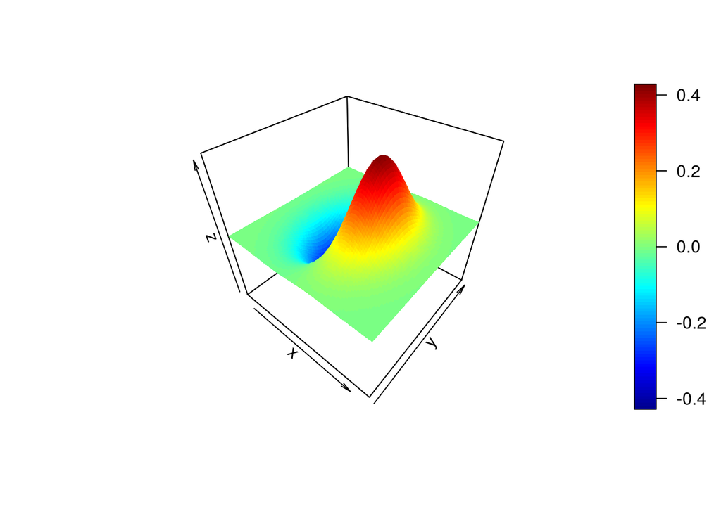

```r
persp3D(x, y, z)
```

It would be nice to be able to rotate this plot to see it from different angles. The command

```r
plotrgl()
```

will open a separate window in which you can click with the mouse and then drag the plot around.

Perhaps you notice that the colour is not changing smoothly, which is due to the fact that we evaluated the function only at a discrete set of gridpoints. To improve the display you can use the `smooth` option:

```r
plotrgl(smooth = TRUE)
```

### Exercise 4

Choose a function of two arguments that you think will produce a particularly beautiful surface plot and display it.

Now commit your R script with all your exercise solutions to your Github repository.